# Estudo de Caso - Porcos Guine

Michel Fiorio

2023-11-24

# Definição do problema de negócio:

## Há diferença significativa no crescimento dos dentes de acordo com o tipo de suplemento usado nos porquinhos da Índia?

# Dataset a ser utilizado:

## Neste estudo usaremos o dataset ToothGrowth disponível no pacote datasets do RStudio

Esse banco de dados contém um conjunto de registros de acompanhamento do efeito da vitamina C no crescimento dos dentes da espécie porquinho da Índia (guinea pigs, em inglês). Pesquisadores ministraram vitamina C para 60 porquinhos e obtiveram o comprimento final dos odontoblastos (células responsáveis pelo comprimento dos dentes) de cada animal após um certo tempo. Foram utilizados três doses diferentes de vitamina C (0,5, 1 e 2 mg) por dois métodos diferentes de entrega, suco de laranja (OJ) ou ácido ascorbico (VC).

# Análise inicial do dataset:

```r
# Carregando pacotes utilizados

library(ggplot2)
library(GGally)
library(moments)
```

```r
# Compreendendo o dataset
?ToothGrowth
```

```
## starting httpd help server ... done
```

```r
# Carregando o dataset
data("ToothGrowth")
```

```r
# Análise exploratória
str(ToothGrowth)
```

```
## 'data.frame':    60 obs. of  3 variables:
##  $ len : num  4.2 11.5 7.3 5.8 6.4 10 11.2 11.2 5.2 7 ...
##  $ supp: Factor w/ 2 levels "OJ","VC": 2 2 2 2 2 2 2 2 2 2 ...
##  $ dose: num  0.5 0.5 0.5 0.5 0.5 0.5 0.5 0.5 0.5 0.5 ...
```

```r
# Análise exploratória
summary(ToothGrowth)
```

```
##       len        supp         dose
##  Min.   : 4.20   OJ:30   Min.   :0.500
##  1st Qu.:13.07   VC:30   1st Qu.:0.500
##  Median :19.25           Median :1.000
##  Mean   :18.81           Mean   :1.167
##  3rd Qu.:25.27           3rd Qu.:2.000
##  Max.   :33.90           Max.   :2.000
```

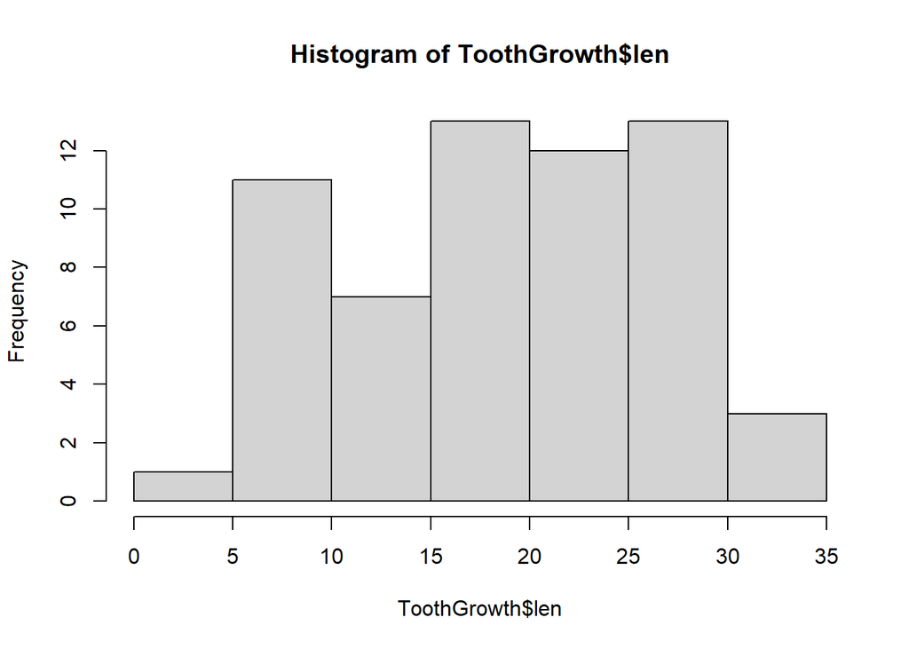

```r
# Histograma da variável len
hist(ToothGrowth$len)
```

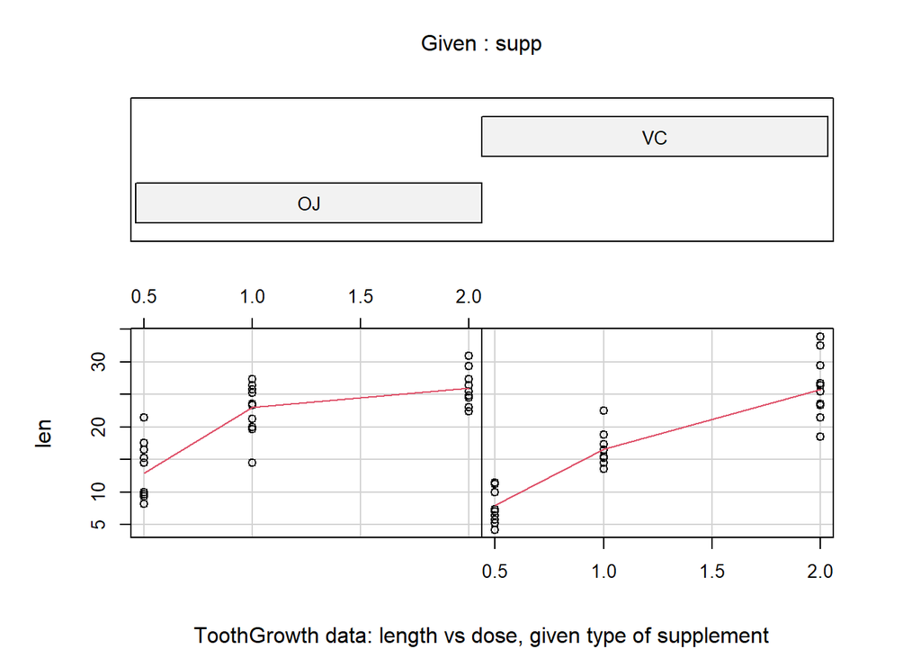

```r
# Gráfico condicionado a variável supp
coplot(len ~ dose | supp, data = ToothGrowth, panel = panel.smooth,
       xlab = "ToothGrowth data: length vs dose, given type of supplement")
```

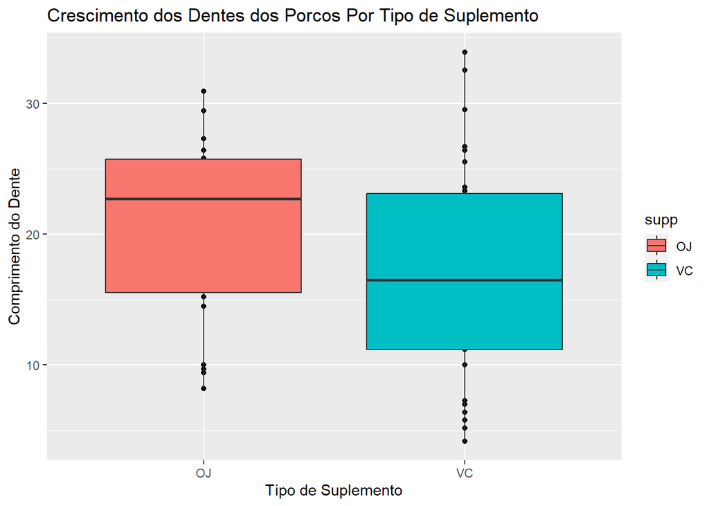

```r
# Boxplots por tipo de suplemento
qplot(supp,
      len,
      data = ToothGrowth,
      main = "Crescimento dos Dentes dos Porcos Por Tipo de Suplemento",
      xlab = "Tipo de Suplemento",
      ylab = "Comprimento do Dente") +
  geom_boxplot(aes(fill = supp))
```

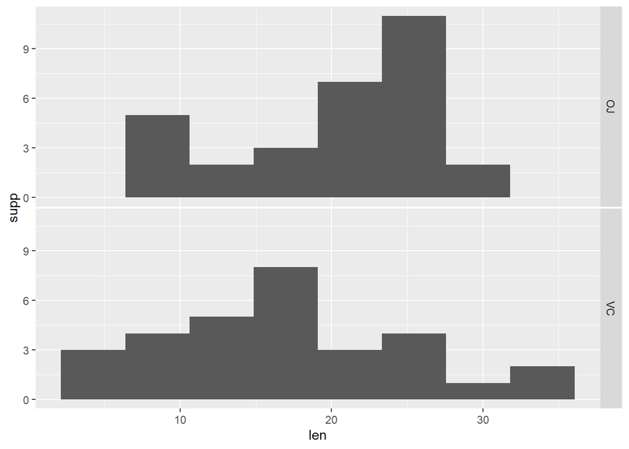

```r
# Histograma por tipo de suplemento
ggally_facethist(ToothGrowth, mapping = ggplot2::aes(x = len, y = supp), bins = 8)
```

# Realização do teste de hipótese estatístico (Teste T) para responder o problema de negócio definido.

## Há diferença significativa no crescimento dos dentes de acordo com o tipo de suplemento usado nos porquinhos da Índia?

Definição das hipóteses do teste.

H0 (hipótese nula) = não há diferença significativa entre as médias dos grupos de suplemento

H1 (hipótese alternativa) = há diferença significativa entre as médias dos grupos de suplemento

Para aplicar o Teste t primeiro precisamos validar as 5 suposições do Teste.

1- Os dados são aleatórios e representativos da população.

2- A variável dependente é contínua.

3- Ambos os grupos são independentes (ou seja, grupos exaustivos e excludentes).

4- Os resíduos do modelo são normalmente distribuídos.

5- A variância residual é homogênea (princípio da homocedasticidade).

Vamos considerar que as suposições 1 a 3 são atendidas

Suposição 4 - Validar que os grupos de suplementos OJ e VC são normalmente distribuídos aplicando o teste de Shapiro Wilk.

```r
# Grupo de suplemento OJ
OJ = subset(ToothGrowth, supp == 'OJ')
```

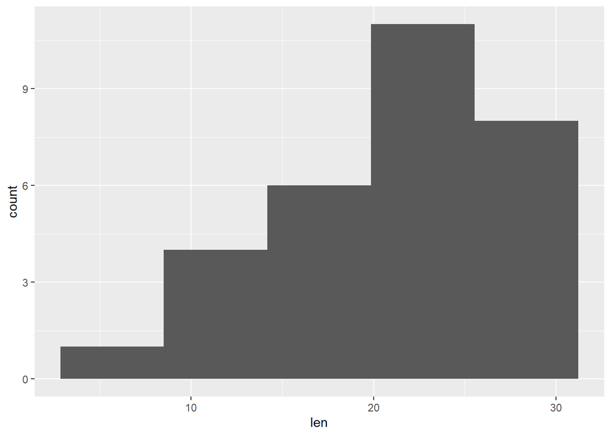

```r
# Histograma
ggplot(data = OJ) + geom_histogram(aes(len), bins = 5)
```

```r
# Teste de Shapiro Wilk
# H0 - a amostra segue uma distribuição normal.
# H1 - a amostra não segue uma distribuição normal.
shapiro.test(OJ$len)
```

```
##
##  Shapiro-Wilk normality test
##
## data:  OJ$len
## W = 0.91784, p-value = 0.02359
```

Resultado do teste para o grupo do suplemento Suco de Laranja (OJ). P- value: 0.02359, rejeitamos a hipótese nula. Os dados não apresentam distribuição normal.

```r
# Verificando coeficiente de assimetria
skewness(OJ$len)
```

```
## [1] -0.5504998
```

Resultado: assimetria negativa, maior concentração de dados nos valores mais altos.

```r
# Coeficiente de curtose
kurtosis(OJ$len)
```

```
## [1] 2.107601
```

```r
# Grupo de suplemento VC
VC <- subset(ToothGrowth, supp == 'VC')
```

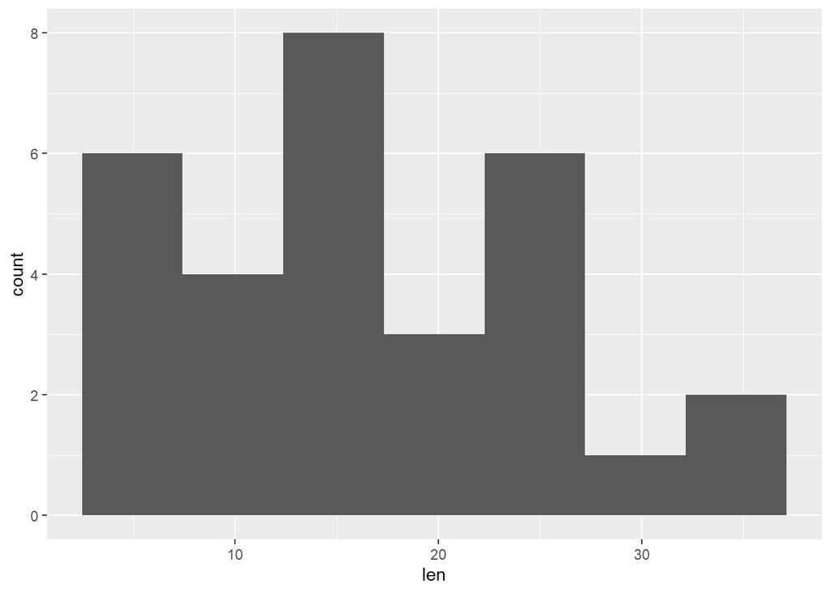

```r
# Histograma
ggplot(data = VC) + geom_histogram(aes(len), bins = 7)
```

```r
# Teste de Shapiro Wilk
# H0 - a amostra segue uma distribuição normal.
# H1 - a amostra não segue uma distribuição normal.
shapiro.test(VC$len)
```

```
##
##  Shapiro-Wilk normality test
##
## data:  VC$len
## W = 0.96567, p-value = 0.4284
```

Resultado do teste para o grupo do suplemento Ácido Ascórbico (VC). P- value: 0.4284, falhamos em rejeitar a hipótese nula. Os dados apresentam distribuição normal.

# Como uma das amostras não possui distribuição normal, não será possível usar o teste T.

# Nesse caso usaremos o teste de Wilcoxon.

Definição das hipóteses do teste.

H0 (hipótese nula) = não há diferença significativa entre as médias dos grupos de suplemento

H1 (hipótese alternativa) = há diferença significativa entre as médias dos grupos de suplemento

```r
# Executando teste de Wilcoxon
wilcox.test(OJ$len, VC$len, alternative = "two.sided")
```

```
##
##  Wilcoxon rank sum test with continuity correction
##
## data:  OJ$len and VC$len
## W = 575.5, p-value = 0.06449
## alternative hypothesis: true location shift is not equal to 0
```

Resultado: p = 0.0645. Não é possível rejeitar a hipótese nula.

# Podemos concluir que não há diferença significativa entre as médias dos grupos que receberam a vitamina através de suco de laranja ou através de acido ascorbico.

# Vamos mudar a pergunta do problema de negócio para validar outra suposição.

## Há diferença significativa no crescimento dos dentes de acordo com a dosagem de suplemento usado nos porquinhos da Índia?

Avaliando os gráficos anteriores parece muito óbvio que haja diferença de resultado de acordo com a dosagem da vitamina dada para cada porco. Vamos validar essa suposição. Vamos comparar os resultados (médias) de len para cada um dos três grupos de dosagem.

```r
# Dividindo os dados em três grupos de acordo com a dosagem de vitamina

dose_0_5 = subset(ToothGrowth, dose == 0.5)
dose_1 = subset(ToothGrowth, dose == 1)
dose_2 = subset(ToothGrowth, dose == 2)
```

# Usaremos o teste de Análise de Variância (ANOVA) na resposta ao novo problema de negócio.

Para aplicar o Teste ANOVA primeiro precisamos validar as 5 suposições do Teste.

1- Os dados são aleatórios e representativos da população.

2- A variável dependente é contínua.

3- Ambos os grupos são independentes (ou seja, grupos exaustivos e excludentes).

4- Os resíduos do modelo são normalmente distribuídos.

5- A variância residual é homogênea (princípio da homocedasticidade).

Vamos considerar que as suposições 1 a 3 são atendidas.

```r
# Aplicando o teste de Shapiro Wilk no grupo dose 0,5mg
shapiro.test(dose_0_5$len)
```

```
##
##  Shapiro-Wilk normality test
##
## data:  dose_0_5$len
## W = 0.94065, p-value = 0.2466
```

Resultado do teste para o grupo de dose 0,5mg. P- value: 0.2466, falhamos em rejeitar a hipótese nula. Os dados apresentam distribuição normal.

```r
# Aplicando o teste de Shapiro Wilk no grupo dose 1mg
shapiro.test(dose_1$len)
```

```
##
##  Shapiro-Wilk normality test
##
## data:  dose_1$len
## W = 0.93134, p-value = 0.1639
```

Resultado do teste para o grupo de dose 1mg. P- value: 0.1639, falhamos em rejeitar a hipótese nula. Os dados apresentam distribuição normal.

```r
# Aplicando o teste de Shapiro Wilk no grupo dose 2mg
shapiro.test(dose_2$len)
```

```
##
##  Shapiro-Wilk normality test
##
## data:  dose_2$len
## W = 0.97775, p-value = 0.9019
```

Resultado do teste para o grupo de dose 2mg. P- value: 0.9019, falhamos em rejeitar a hipótese nula. Os dados apresentam distribuição normal.

Suposição 5 - Vamos realizar o teste F

H0 - As Médias dos dados tem a mesma variância.

H1 - As médias dos dados não tem a mesma variância.

```r
# Teste F entre os grupos dose 0,5mg e 1mg
var.test(dose_0_5$len, dose_1$len)
```

```
##
##  F test to compare two variances
##
## data:  dose_0_5$len and dose_1$len
## F = 1.0386, num df = 19, denom df = 19, p-value = 0.9351
## alternative hypothesis: true ratio of variances is not equal to 1
## 95 percent confidence interval:
##  0.4110751 2.6238736
## sample estimates:
## ratio of variances
##           1.038561
```

Resultado do teste: p-value = 0.9351. Falhamos em rejeitar a hipótese nula. Os dados apresentam mesma variância.

```r
# Teste F entre os grupos dose 1mg e 2mg
var.test(dose_1$len, dose_2$len)
```

```
##
##  F test to compare two variances
##
## data:  dose_1$len and dose_2$len
## F = 1.3687, num df = 19, denom df = 19, p-value = 0.5005
## alternative hypothesis: true ratio of variances is not equal to 1
## 95 percent confidence interval:
##  0.5417489 3.4579584
## sample estimates:
## ratio of variances
##           1.368702
```

Resultado do teste: p-value = 0.5005. Falhamos em rejeitar a hipótese nula. Os dados apresentam mesma variância.

Todas as suposições validadas.

Hipóteses do teste:

H0: não há diferença significativa entre as médias dos grupos

H1: há diferença significativa entre as médias dos grupos

```r
ANOVA = aov(len ~ dose, ToothGrowth)
summary(ANOVA)
```

```
##             Df Sum Sq Mean Sq F value   Pr(>F)
## dose         1   2224  2224.3   105.1 1.23e-14 ***
## Residuals   58   1228    21.2
## ---
## Signif. codes:  0 '***' 0.001 '**' 0.01 '*' 0.05 '.' 0.1 ' ' 1
```

Resultado do teste ANOVA: p- value = 1.23e-14, rejeitamos a hipótese nula.

# Verificamos pelo resultado do ANOVA que há diferenças significativas entre as médias dos grupos que utilizaram doses diferentes de vitamina C.

# Conclusão:

# O tipo de método de entrega da vitamina C não afeta significativamente o comprimento dos dentes dos porquinhos.

# Já a dose da vitamina utilizada tem forte relação com o comprimento dos dentes.